# Unit 12 For Live Session

Chad Madding

March 22, 2020

## Question Of Interest

The data set (LA_Cmort_Study.csv) is a portion of the data taken from a study (Shumway 1988) on the possible effects of pollution and temperature on weekly cardiac mortality (heart attacks) in Los Angeles County.

**Your goal is to utilize all given information to provide the most useful forecasts for the next 20 weeks of cardiac mortality.**

You should include plots, tables, and charts to help make your analysis and inferences clear to your peers.

Start by reading in the data and see what it looks like.

```r
CM = read.csv("la_cmort_study.csv", header = TRUE)
#Look at the first few rows
head(CM)
```

```
##   Week  temp  part  cmort
## 1    1 72.38 72.72  97.85
## 2    2 67.19 49.60 104.64
## 3    3 62.94 55.68  94.36
## 4    4 72.49 55.16  98.05
## 5    5 74.25 66.02  95.85
## 6    6 67.88 44.01  95.98
```

## Visualaze The Data

Make a matrix of plots with the LA_Cmort data set.

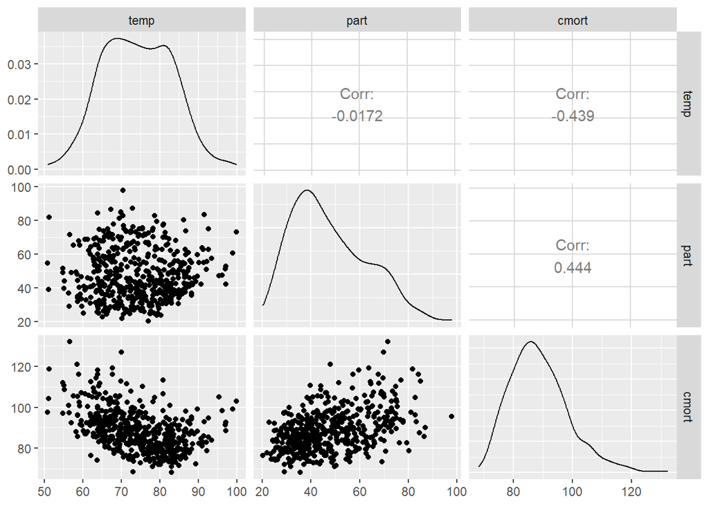

#### ARIMA 1 MLR with Cor Errors (no lag, no seasonl categorical variable)

First we will forecast the Particles (part). The $freq show a peek around 0.0192 showing some sign of a 52 week annual trend.

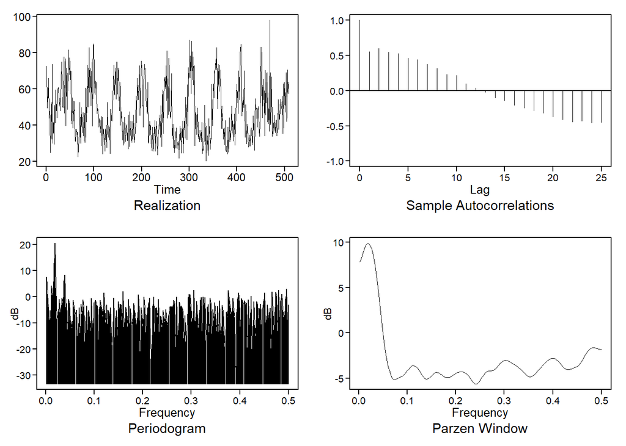

```r
#plot just the Particles (part)
plotts.sample.wge(CM$part) #peek in freq near .0192/1=52.08 (annual)
```

Using multivariate to forecast

```r
CMnoX=CM[2:4]
#install.packages("vars")
# VAR and VARselect are from CRAN package vars
VARselect(CMnoX, lag.max = 15, type = "const",season = NULL, exogen = NULL)
```

```
## $selection
## AIC(n)  HQ(n)  SC(n) FPE(n)
##      9      5      2      9
##
## $criteria
##                   1           2           3           4           5           6
## AIC(n)     11.83703    11.35715    11.32459    11.28105    11.22936    11.20971
## HQ(n)      11.87717    11.42740    11.42495    11.41152    11.38994    11.40039
## SC(n)      11.93927    11.53607    11.58020    11.61334    11.63834    11.69536
## FPE(n) 138278.93633 85575.42617 82834.75080 79307.32148 75314.81580 73852.10868
##                  7           8           9          10          11          12
## AIC(n)    11.21438    11.19428    11.17282    11.17835    11.18313    11.17328
## HQ(n)     11.43517    11.44518    11.45383    11.48947    11.52436    11.54461
## SC(n)     11.77672    11.83330    11.88852    11.97074    12.05221    12.11903
## FPE(n) 74202.71501 72731.98582 71195.36032 71599.87436 71954.70797 71262.38608
##                 13          14          15
## AIC(n)    11.17307    11.17335    11.17635
## HQ(n)     11.57451    11.60490    11.63801
## SC(n)     12.19551    12.27247    12.35215
## FPE(n) 71263.64357 71302.45977 71537.90535
```

```r
#VARselect picks p=2 (using BIC)
lsfit=VAR(CMnoX,p=2,type="const")
preds=predict(lsfit,n.ahead=20)
# preds$fcst$ are the VAR forecasts for x1.  Similar for x2
#this will list out just the forcast
preds$fcst$temp
```

```
##           fcst    lower    upper       CI
##  [1,] 71.25383 59.19228 83.31538 12.06155
##  [2,] 69.90957 57.54192 82.27723 12.36765
##  [3,] 70.19691 56.98563 83.40820 13.21129
##  [4,] 69.65798 56.07989 83.23608 13.57810
##  [5,] 69.77733 55.74554 83.80912 14.03179
##  [6,] 69.64721 55.23042 84.06400 14.41679
##  [7,] 69.75578 54.95005 84.56152 14.80574
##  [8,] 69.81715 54.65589 84.97841 15.16126
##  [9,] 69.96410 54.47041 85.45778 15.49368
## [10,] 70.11506 54.32006 85.91006 15.79500
## [11,] 70.29838 54.23133 86.36544 16.06705
## [12,] 70.49071 54.18112 86.80030 16.30959
## [13,] 70.69483 54.17058 87.21908 16.52425
## [14,] 70.90282 54.19003 87.61560 16.71279
## [15,] 71.11275 54.23547 87.99004 16.87729
## [16,] 71.32107 54.30113 88.34102 17.01994
## [17,] 71.52578 54.38283 88.66872 17.14294
## [18,] 71.72492 54.47651 88.97334 17.24842
## [19,] 71.91718 54.57878 89.25557 17.33839
## [20,] 72.10147 54.68670 89.51624 17.41477
```

Transform the Particles (part) to remove the seasonality.

```r
CM_52 = artrans.wge(CM$part, c(rep(0,51),1))
```

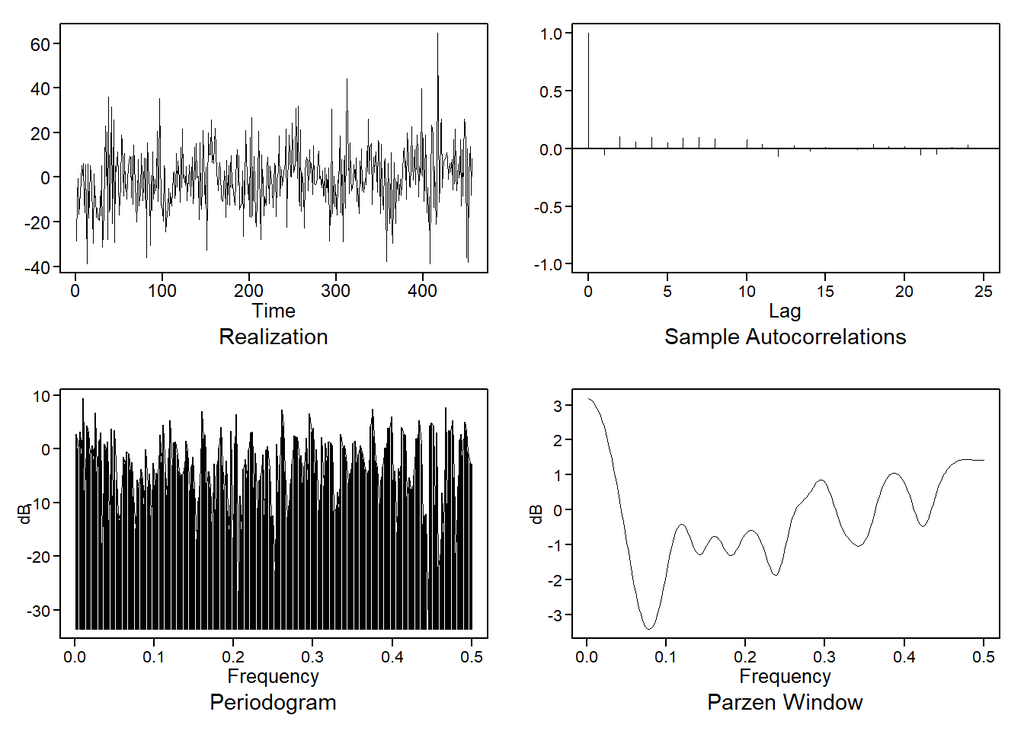

```r
plotts.sample.wge(CM_52) #looks like some low freq?
```

```r
aic5.wge(CM_52) #picks ARMA(2,1) assume stationary
aic5.wge(CM_52,type = "bic") #picks ARMA(2,1)
ljung.wge(CM_52)$pval #FTR Ho
ljung.wge(CM_52, K = 48)$pval #FTR Ho
#Going with white noise despite peak at 0 in Spec D.
#est = est.arma.wge(CM_52, p = 3, q = 2)
#CM_52_AR2_MA1 = artrans.wge(CM_52,est$phi)
predsPart = fore.aruma.wge(CM$part,s = 52, n.ahead = 20, limits = F)
```

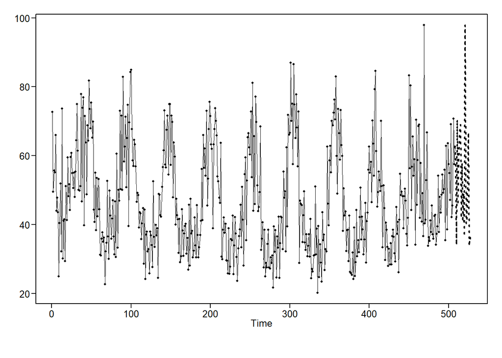

Next we will forecast temperature (Temp).

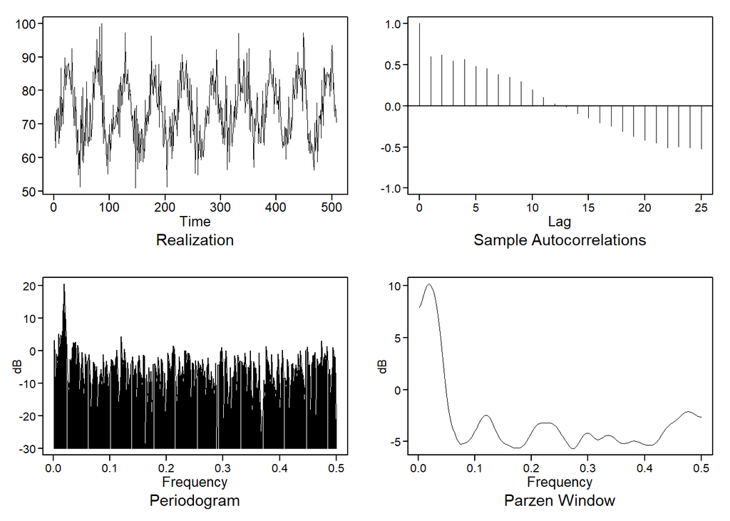

```r
#forecast Temp
plotts.sample.wge(CM$temp) #freq near .0192 (annual)
```

```r
CM_52 = artrans.wge(CM$temp, c(rep(0,51),1))
```

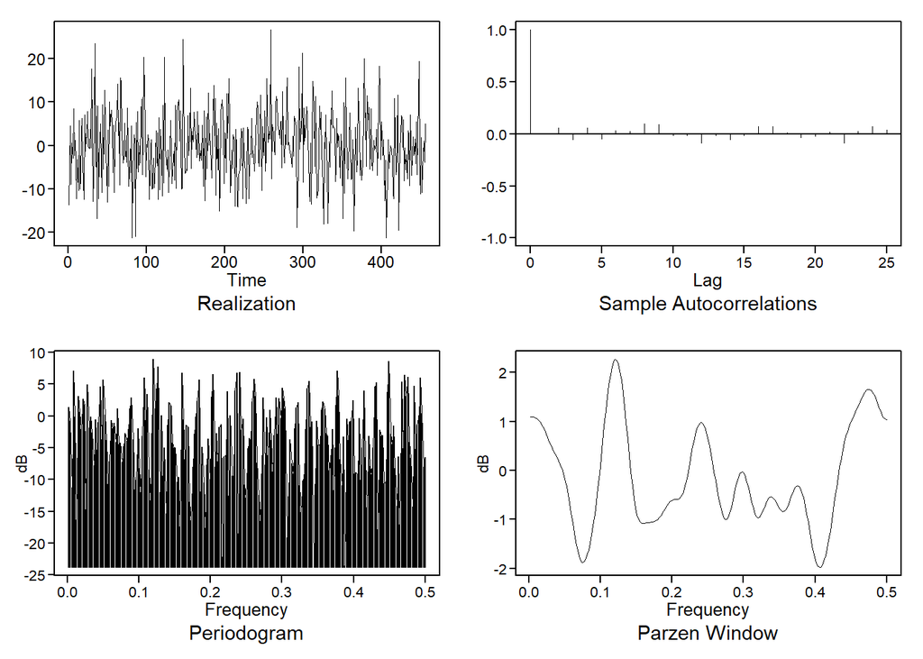

```r
plotts.sample.wge(CM_52) #looks like some low freq?
```

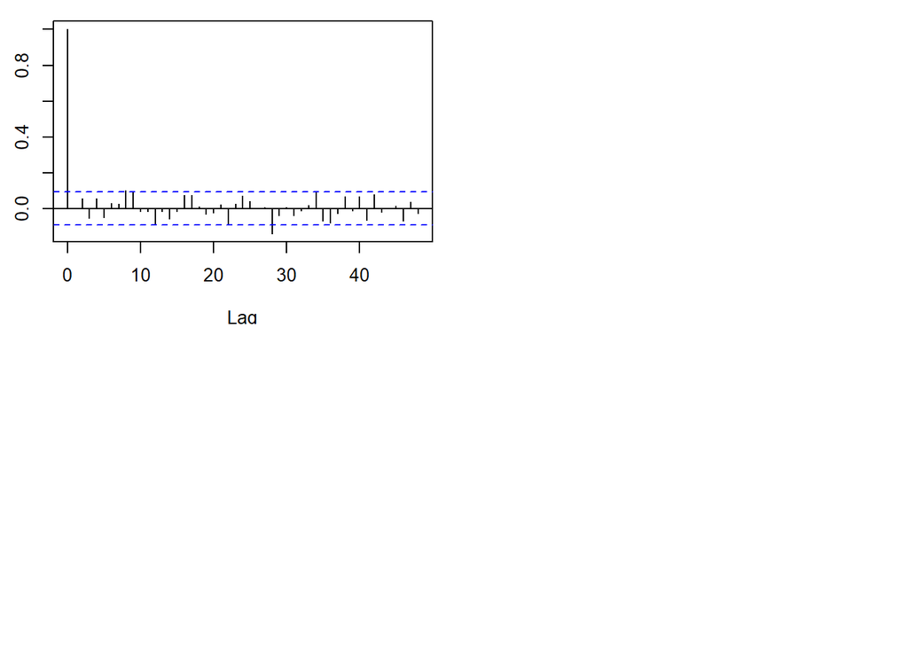

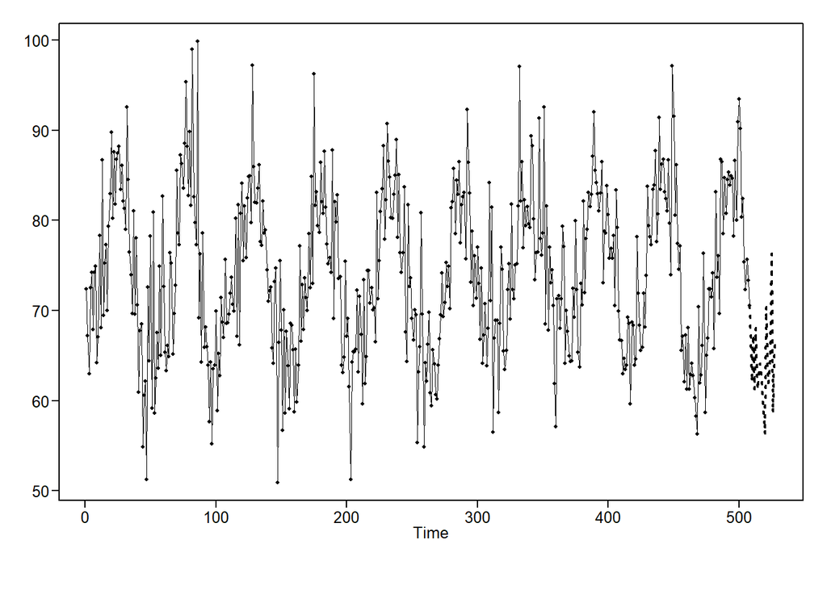

```r
aic5.wge(CM_52) #picks ARMA(0,0)
aic5.wge(CM_52,type = "bic") #picks ARMA(0,0)
ljung.wge(CM_52)$pval
ljung.wge(CM_52, K = 48)$pval #barely rejects
acf(CM_52,lag.max = 48) # acf looks consistent with white noise
predsTemp = fore.aruma.wge(CM$temp,s = 52, n.ahead = 20, limits = F)
```

Looking at cardiac mortality (heart attacks) in Los Angeles County based on temperature, particles and Week.

```r
# Model cmort based on predicted part and temp using MLR with Cor Erros
ksfit = lm(cmort~temp+part+Week, data = CM)
phi = aic.wge(ksfit$residuals)
```

Fit an ARIMA with the phi from above (2). Binding the temperature, particle and week data with cbind.

```r
fit = arima(CM$cmort,order = c(phi$p,0,0), seasonal = list(order = c(1,0,0), period = 52), xreg = cbind(CM$temp, CM$part, CM$Week))
```

Visually the acf is showing white noise. Now we need to check for whiteness of residuals with the Ljung-Box Test.

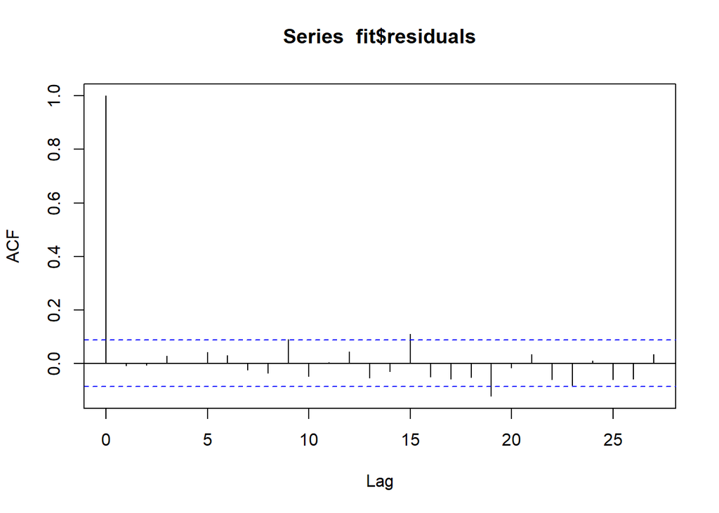

```r
#First visualize the residuals
acf(fit$residuals)
```

```r
#Run the test with the default 24 and 48 maximum lag for sample autocorrelations to be used.
ljung.wge(fit$residuals) # pval = .048
```

```
## Obs -0.008773997 -0.006778 0.02847037 0.001592821 0.04173621 0.03014614 -0.02519791 -0.03614844 0.08896799 -0.04873154 0.003349583 0.04272511 -0.05378803 -0.03121467 0.1104465 -0.0511791 -0.05781976 -0.05203572 -0.1226383 -0.01661192 0.03274971 -0.06125045 -0.08319911 0.009083812
```

```
## $test
## [1] "Ljung-Box test"
##
## $K
## [1] 24
##
## $chi.square
## [1] 36.59418
##
## $df
## [1] 24
##
## $pval
## [1] 0.04801085
```

```r
ljung.wge(fit$residuals, K = 48) # pval = .002
```

[output not shown]

```
## $test
## [1] "Ljung-Box test"
##
## $K
## [1] 48
##
## $chi.square
## [1] 79.51156
##
## $df
## [1] 48
##
## $pval
## [1] 0.002852882
```

Load the forecast Part and Temp data in a data frame. This will extend the week from 509 to 528 with **seq**.

```r
next20 = data.frame(temp = predsTemp$f, part = predsPart$f, Week = seq(509,528,1))
```

This will get the predictions

```r
#get predictions
predsCMort = predict(fit,newxreg = next20)
```

plot next 20 cmort wrt time

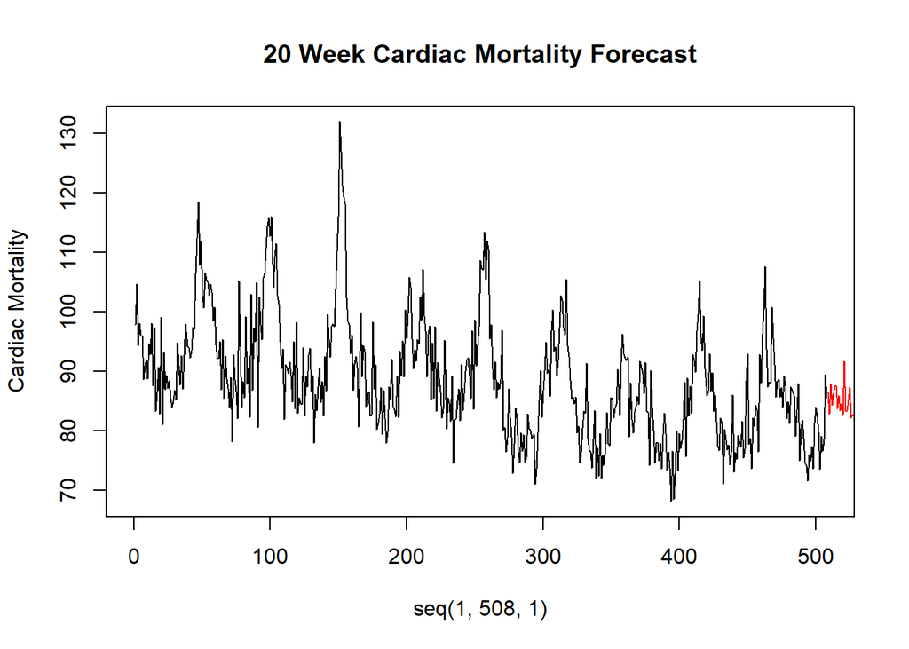

```r
plot(seq(1,508,1), CM$cmort, type = "l",xlim = c(0,508), ylab = "Cardiac Mortality", main = "20 Week Cardiac Mortality Forecast")
lines(seq(509,528,1), predsCMort$pred, type = "l", col = "red")
```

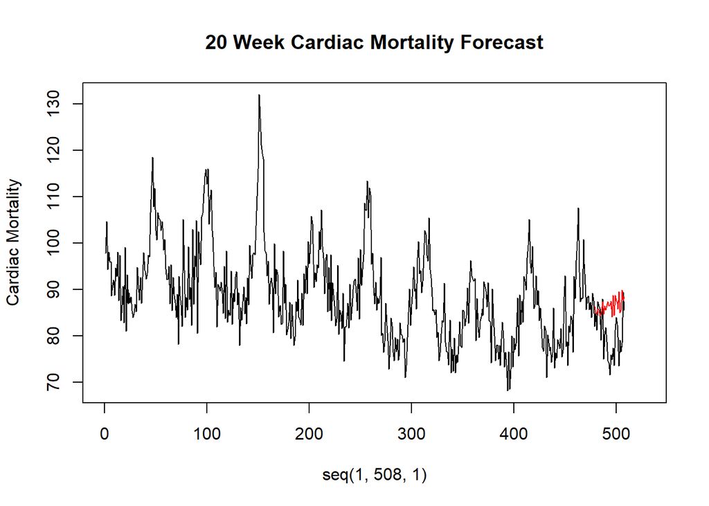

```r
#Find ASE  Need to forecast last 30 of known series using dplyr lag.
CMsmall = CM[1:478,]
CMsmall$temp_1 = dplyr::lag(CMsmall$temp,1)
CM$temp_1 = dplyr::lag(CM$temp,1)
ksfit = lm(cmort~temp_1+part+Week, data = CMsmall)
phi = aic.wge(ksfit$residuals)

fit = arima(CMsmall$cmort,order = c(phi$p,0,0), seasonal = list(order = c(1,0,0), period = 52), xreg = cbind(CMsmall$temp, CMsmall$part, CMsmall$Week))

last30 = data.frame(temp = CM$temp_1[479:508], part = CM$part[479:508], Week = seq(479,508,1))
#get predictions
predsCMort = predict(fit,newxreg = last30)

plot(seq(1,508,1), CM$cmort, type = "l",xlim = c(0,528), ylab = "Cardiac Mortality", main = "20 Week Cardiac Mortality Forecast")
lines(seq(479,508,1), predsCMort$pred, type = "l", col = "red")
```

```r
ASE_ARMA1 = mean((CM$cmort[479:508] - predsCMort$pred)^2)
ASE_ARMA1
```

[output not shown]

#### ARIMA2: attempt at categorical variable for week but arima takes only continuous variables

forecast Particles

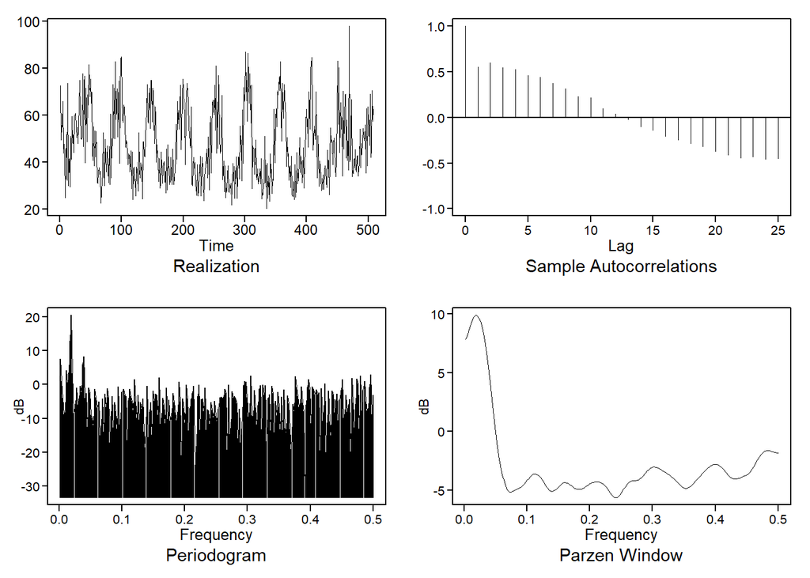

```r
CM = read.csv("la_cmort_study.csv", header = TRUE)
plotts.sample.wge(CM$part) #freq near .0192 (annual)
```

```r
CM_52 = artrans.wge(CM$part, c(rep(0,51),1))
```

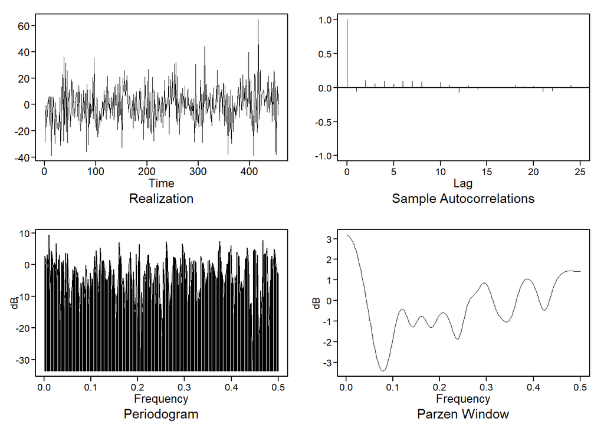

```r
plotts.sample.wge(CM_52) #looks like some low freq?
```

```r
aic5.wge(CM_52) #picks ARMA(2,1) assume stationary
aic5.wge(CM_52,type = "bic") #picks ARMA(0,0)
ljung.wge(CM_52)$pval #FTR Ho
ljung.wge(CM_52, K = 48)$pval #FTR Ho
#Going with white noise despite peak at 0 in Spec D.
#est = est.arma.wge(CM_52, p = 3, q = 2)
#CM_52_AR2_MA1 = artrans.wge(CM_52,est$phi)
predsPart = fore.aruma.wge(CM$part,s = 52, n.ahead = 20)
```

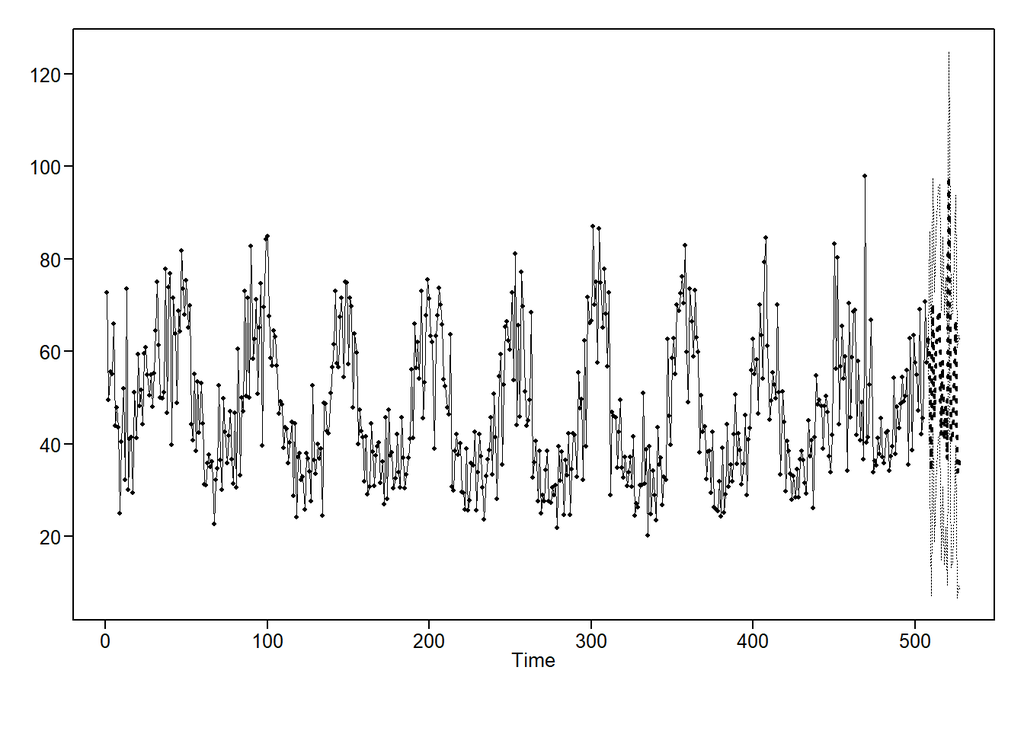

forecast Temp

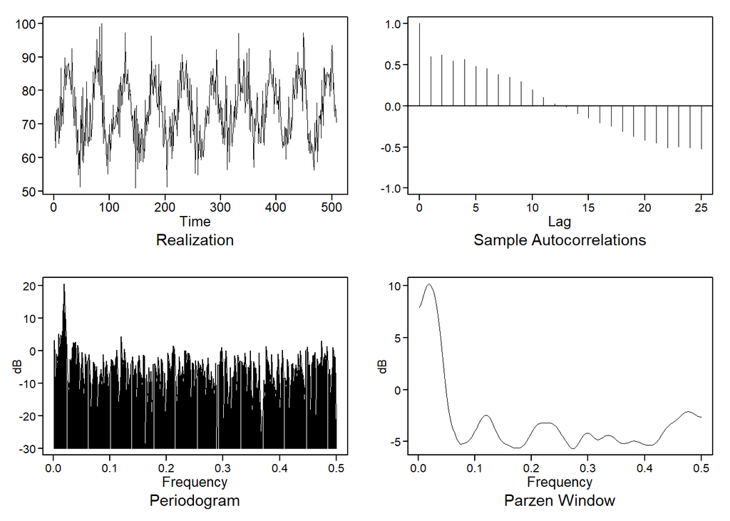

```r
plotts.sample.wge(CM$temp) #freq near .0192 (annual)
```

```r
CM_52 = artrans.wge(CM$temp, c(rep(0,51),1))
```

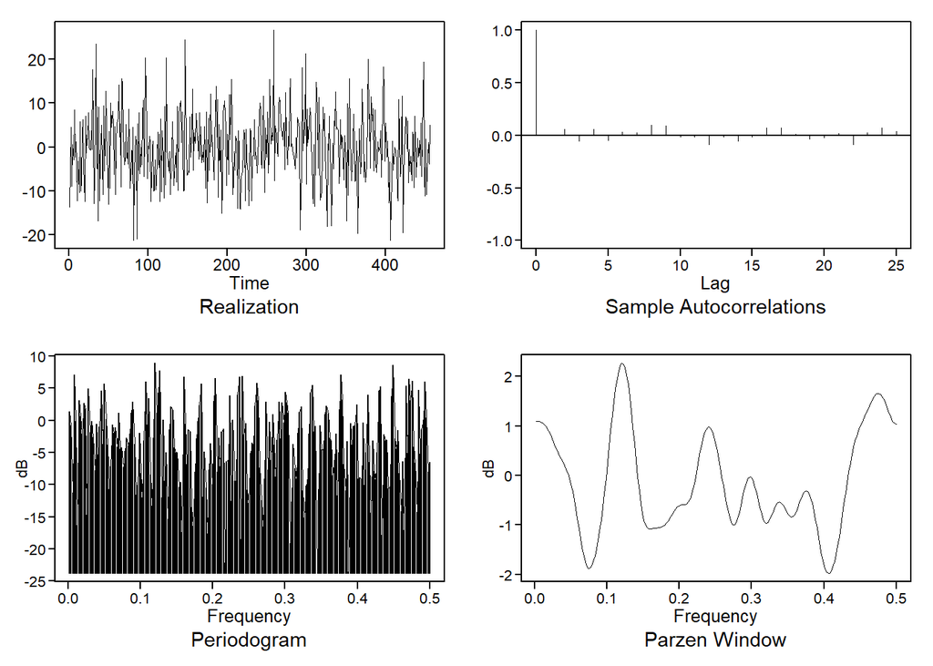

```r
plotts.sample.wge(CM_52) #looks like some low freq?
```

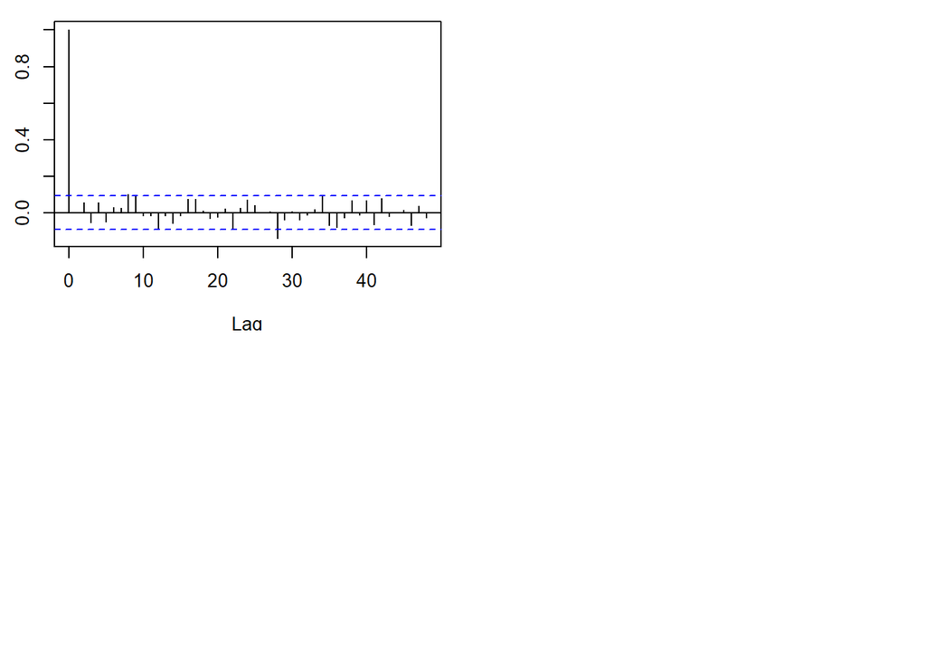

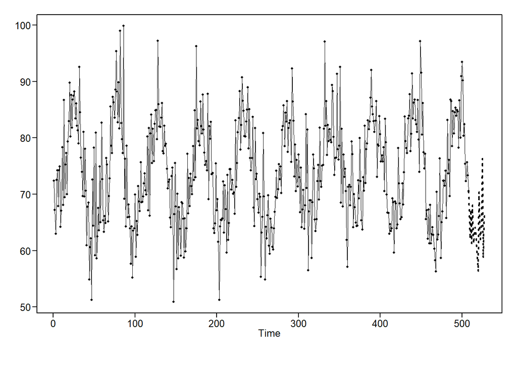

```r
aic5.wge(CM_52) #picks ARMA(0,0)
aic5.wge(CM_52,type = "bic") #picks ARMA(0,0)
ljung.wge(CM_52)$pval
ljung.wge(CM_52, K = 48)$pval #barely rejects
acf(CM_52,lag.max = 48) # acf looks consistent with white noise
predsTemp = fore.aruma.wge(CM$temp,s = 52, n.ahead = 20, limits = F)
```

Model **cmort** based on predicted **part** and **temp** using Multiple Linear Regression (MLR) with correlation errors.

```r
CM$FWeek = as.factor(CM$Week%%52)
ksfit = lm(cmort~temp+part+Week+FWeek, data = CM)
phi = aic.wge(ksfit$residuals)
fit = arima(CM$cmort,order = c(phi$p,0,0), xreg = cbind(CM$temp, CM$part, CM$Week, CM$FWeek))
```

Check for whiteness of residuals with a visual test and the Ljung-Box Test

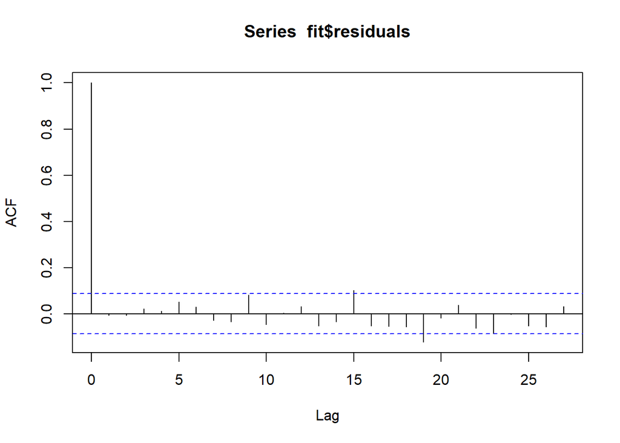

```r
acf(fit$residuals)
```

```r
ljung.wge(fit$residuals) # pval = .066
```

[output not shown]

```
## $test
## [1] "Ljung-Box test"
##
## $K
## [1] 24
##
## $chi.square
## [1] 35.17006
##
## $df
## [1] 24
##
## $pval
## [1] 0.06591877
```

```r
ljung.wge(fit$residuals, K = 48) # pval = .0058
```

[output not shown]

```
## $test
## [1] "Ljung-Box test"
##
## $K
## [1] 48
##
## $chi.square
## [1] 76.25112
##
## $df
## [1] 48
##
## $pval
## [1] 0.005835517
```

load the forecasted Part and Temp in a data frame

```r
next20 = data.frame(temp = predsTemp$f, part = predsPart$f, Week = seq(509,528,1), FWeek = as.factor(seq(509,528,1)%%52))
```

get predictions - predict residuals

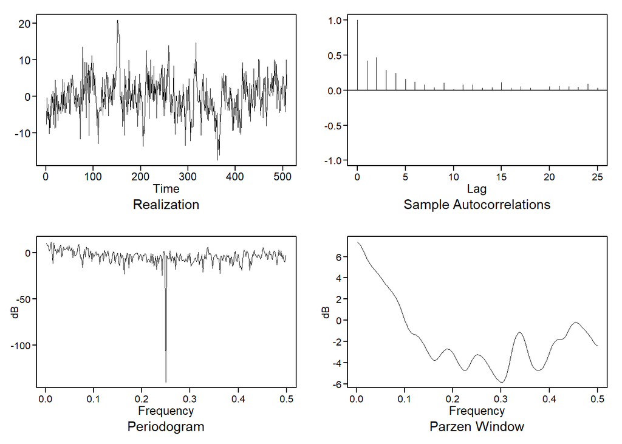

[output not shown]

[output cut: 134 more lines]

```r
plotts.sample.wge(ksfit$residuals)
```

```r
phi = aic.wge(ksfit$residuals)
resids = fore.arma.wge(ksfit$residuals,phi = phi$phi,n.ahead = 20, limits = F)
```

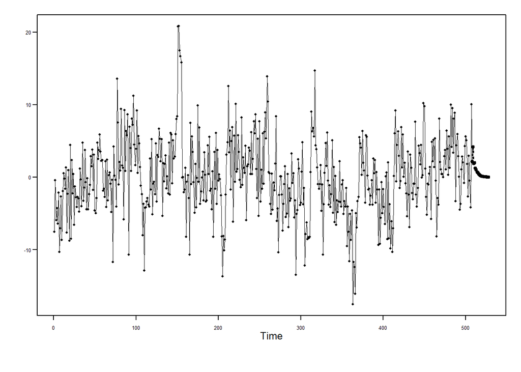

```r
#predict trend manually
preds = predict(ksfit, newdata = next20)

predsFinal = preds + resids$f
```

Plot the next 20 cmort wrt time

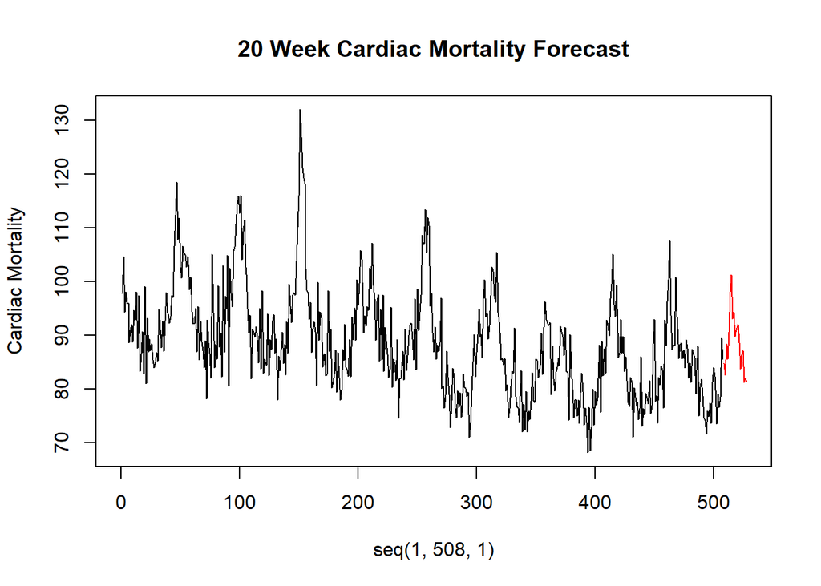

```r
plot(seq(1,508,1), CM$cmort, type = "l",xlim = c(0,528), ylab = "Cardiac Mortality", main = "20 Week Cardiac Mortality Forecast")
lines(seq(509,528,1), predsFinal, type = "l", col = "red")
```

```r
length(predsFinal)
```

```
## [1] 20
```

To Find the ASE we need to forecast last 30 of the known series.

```r
CMsmall = CM[2:478,]
ksfit = lm(cmort~temp+part+Week+FWeek, data = CMsmall)
phi = aic.wge(ksfit$residuals)
fit = arima(CMsmall$cmort,order = c(phi$p,0,0), seasonal = list(order = c(1,0,0), period = 52), xreg = cbind(CMsmall$temp1, CMsmall$part, CMsmall$Week, CMsmall$FWeek))

last30 = data.frame(temp = CM$temp[479:508], part = CM$part[479:508], Week = seq(479,508,1), FWeek = as.factor(seq(479,508,1)%%52))
```

Predict residuals manually

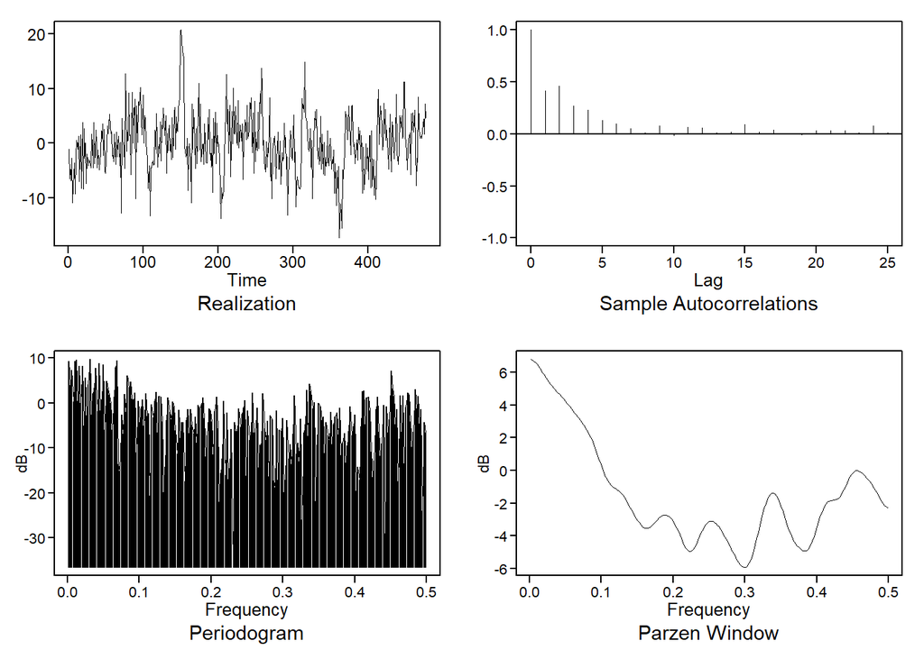

[output not shown]

[output cut: 134 more lines]

```r
plotts.sample.wge(ksfit$residuals)
```

```r
phi = aic.wge(ksfit$residuals)
resids = fore.arma.wge(ksfit$residuals,phi = phi$phi,n.ahead = 30)
```

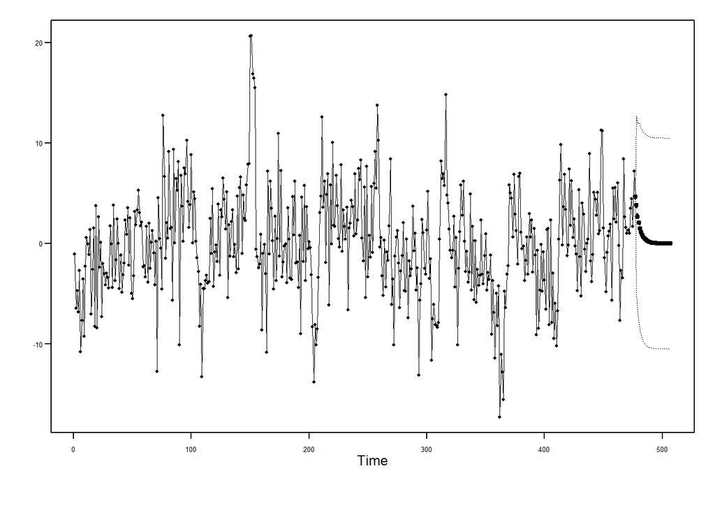

Predict trend manually

```r
preds = predict(ksfit, newdata = last30)
#Final using the trend and residuals
predsFinal = preds + resids$f
```

Plot and print out the ASE

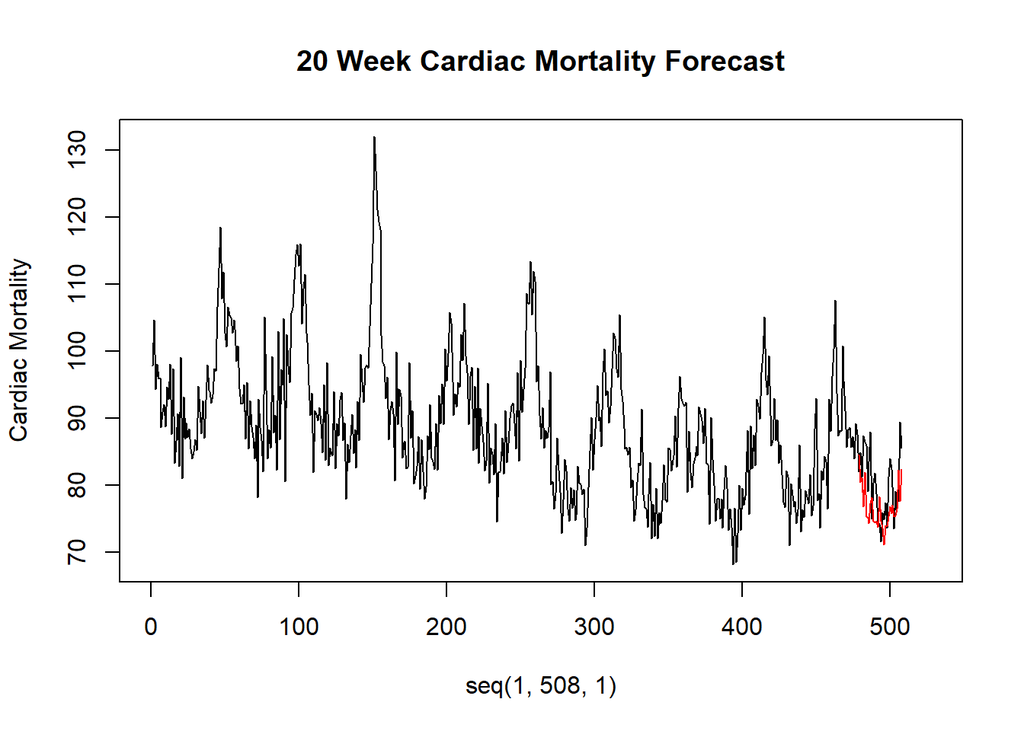

```r
plot(seq(1,508,1), CM$cmort, type = "l",xlim = c(0,528), ylab = "Cardiac Mortality", main = "20 Week Cardiac Mortality Forecast")
lines(seq(479,508,1), predsFinal, type = "l", col = "red")
```

```r
ASE_ARMA2 = mean((CM$cmort[479:508] - predsFinal)^2,na.rm = TRUE)
ASE_ARMA2
```

```
## [1] 32.45511
```

#### VAR Model

**VAR Model Forecasts Seasonally Differenced Data**

Difference all series to make them stationary which is an assumption of VAR.  
They do not have to be white, just stationary.

```r
CM = read.csv("la_cmort_study.csv", header = TRUE)
CM_52 = artrans.wge(CM$cmort,c(rep(0,51),1))
```

[figure not shown]

```r
Part_52 = artrans.wge(CM$part,c(rep(0,51),1))
```

```r
Temp_52 = artrans.wge(CM$temp,c(rep(0,51),1))
```

```r
#VARSelect on Differenced Data chooses 2
VARselect(cbind(CM_52, Part_52, Temp_52),lag.max = 10, type = "both")
```

```
## $selection
## AIC(n)  HQ(n)  SC(n) FPE(n)
##      4      2      2      4
##
## $criteria
##                   1            2            3            4            5
## AIC(n)     12.87263     12.74039     12.74236     12.71258     12.71419
## HQ(n)      12.92701     12.82739     12.86198     12.86483     12.89906
## SC(n)      13.01054     12.96103     13.04575     13.09871     13.18307
## FPE(n) 389506.60462 341260.26330 341940.07226 331918.68995 332470.16877
##                   6            7            8            9           10
## AIC(n)     12.74034     12.75365     12.75100     12.73260     12.75196
## HQ(n)      12.95784     13.00376     13.03374     13.04796     13.09995
## SC(n)      13.29196     13.38800     13.46810     13.53244     13.63454
## FPE(n) 341302.58712 345905.71709 345034.37801 338794.95293 345484.81652
```

```r
#VAR with p = 2
CMortDiffVAR = VAR(cbind(CM_52, Part_52, Temp_52),type = "both",p = 2)
preds=predict(CMortDiffVAR,n.ahead=20)

#We have predicted differences .... calculate actual cardiac mortalities
startingPoints = CM$cmort[428:457]
CMortForcasts = preds$fcst$CM_52[,1:3] + startingPoints

#Plot
while (!is.null(dev.list()))  dev.off()
plot(seq(1,508,1), CM$cmort, type = "l",xlim = c(0,528), ylab = "Cardiac Mortality", main = "20 Week Cardiac Mortality Forecast")
lines(seq(509,528,1), as.data.frame(CMortForcasts)$fcst, type = "l", col = "red")

ASE_VAR1 = mean((CM$cmort[489:508] - CMortForcasts[,1])^2)
ASE_VAR1
```

```
## [1] 25.47226
```

### Modeling with the sales data set

find the ASE for forecasts of the last five observations of the sales data set example for both the MLE model (using ARIMA) and the VAR model we fit.

We fit several models using the arima() function, you should pick the one you feel is the best model (maybe with the lowest AIC?).

Your slides should include each of the following:

- Your code
- Enough visual aids to describe how you calculated the ASE for each model
- The ASE for each model
- Which model you feel is better in that respect, and why.

Read in and visualize the sales data

```r
BSales = read.csv("businesssales.csv", header = TRUE)

## Visualaze The Data
head(BSales)
```

```
##   X    sales    ad_tv ad_online  discount
## 1 1 52.61137 5.105617  3.646744 0.0000000
## 2 2 50.46478 5.233105  3.381140 0.0000000
## 3 3 50.15374 5.202212  3.550546 0.7571115
## 4 4 49.68254 5.386699  3.570285 3.5303790
## 5 5 50.44613 4.961060  3.460531 5.4983130
## 6 6 51.72145 5.153207  3.801946 7.2211060
```

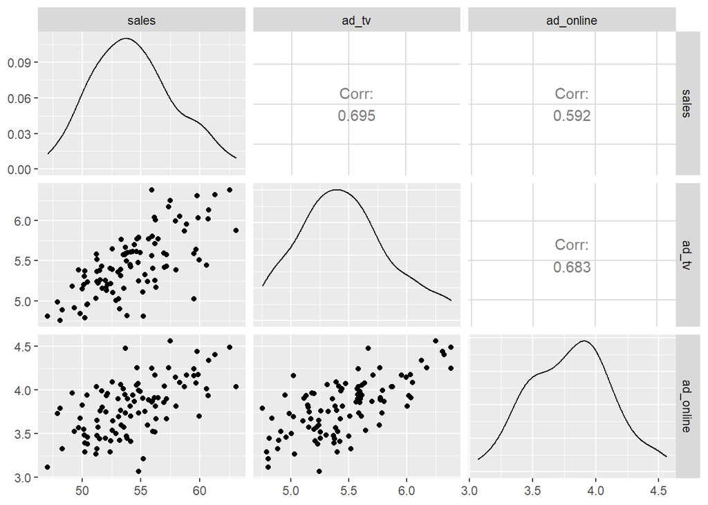

```r
#Make a matrix of plots with the BSales data set.
ggpairs(BSales[2:4]) #matrix of scatter plots
```

#### MLR Modeling

**Model 1**

All data with no lag and no trend

```r
ksfit=lm(sales~ad_tv+ad_online+discount, data = BSales)
aic.wge(ksfit$residuals,p=0:8, q=0)  # AIC picks p=7
```

```
## $type
## [1] "aic"
##
## $value
## [1] 1.101655
##
## $p
## [1] 7
##
## $q
## [1] 0
##
## $phi
## [1]  0.3914830668  0.1263257053 -0.3764190275 -0.0005409533  0.1006855558
## [6]  0.2148095958  0.1476114131
##
## $theta
## [1] 0
##
## $vara
## [1] 2.564221
```

```r
fit=arima(BSales$sales,order=c(7,0,0),xreg=BSales[,3:5])
fit
```

```
##
## Call:
## arima(x = BSales$sales, order = c(7, 0, 0), xreg = BSales[, 3:5])
##
## Coefficients:
##          ar1      ar2     ar3     ar4     ar5     ar6      ar7  intercept
##       1.4734  -0.8921  0.0749  0.0919  0.0438  0.1865  -0.1287    54.5513
## s.e.  0.1107   0.1963  0.2167  0.2057  0.2049  0.1852   0.1080     2.2040
##        ad_tv  ad_online  discount
##       0.0703    -0.0934   -0.1514
## s.e.  0.3434     0.2075    0.1315
##
## sigma^2 estimated as 1.411:  log likelihood = -161.1,  aic = 346.21
```

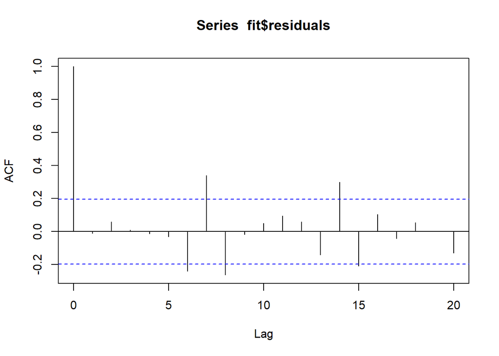

```r
acf(fit$residuals)
```

```r
ltest = ljung.wge(fit$resid)
```

[output not shown]

```r
ltest$pval
```

```
## [1] 7.445469e-06
```

ASE for model with no lag and no trend (last 5)

```r
#Cut off the last 5
BSales2 = BSales[1:95,]
ksfit=lm(sales~ad_tv+ad_online+discount, data = BSales2)
aic.wge(ksfit$residuals,p=0:8, q=0)  # AIC picks p=7
```

```
## $type
## [1] "aic"
##
## $value
## [1] 1.119875
##
## $p
## [1] 7
##
## $q
## [1] 0
##
## $phi
## [1]  0.39110624  0.13440258 -0.39244949  0.03048536  0.07647737  0.19178372
## [7]  0.16884555
##
## $theta
## [1] 0
##
## $vara
## [1] 2.589471
```

```r
fit=arima(BSales2$sales,order=c(7,0,0),xreg=cbind(BSales2$ad_tv,BSales2$ad_online,BSales2$discount))
fit
```

```
##
## Call:
## arima(x = BSales2$sales, order = c(7, 0, 0), xreg = cbind(BSales2$ad_tv, BSales2$ad_online,
##     BSales2$discount))
##
## Coefficients:
##          ar1      ar2     ar3    ar4     ar5     ar6      ar7  intercept
##       1.4819  -0.9000  0.1156  0.073  0.0122  0.2405  -0.1444    55.5453
## s.e.  0.1129   0.2002  0.2214  0.213  0.2141  0.1924   0.1106     2.3458
##       cbind(BSales2$ad_tv, BSales2$ad_online, BSales2$discount)1
##                                                          -0.0418
## s.e.                                                      0.3508
##       cbind(BSales2$ad_tv, BSales2$ad_online, BSales2$discount)2
##                                                          -0.1579
## s.e.                                                      0.2143
##       cbind(BSales2$ad_tv, BSales2$ad_online, BSales2$discount)3
##                                                          -0.1140
## s.e.                                                      0.1489
##
## sigma^2 estimated as 1.426:  log likelihood = -153.65,  aic = 331.29
```

```r
preds = predict(fit, newxreg = cbind(BSales$ad_tv[96:100],BSales$ad_online[96:100],BSales$discount[96:100]))
ASE1 = mean((BSales$sales[96:100] - preds$pred)^2)
ASE1
```

```
## [1] 57.1069
```

```r
while (!is.null(dev.list()))  dev.off()

plot(seq(1,100,1), BSales$sales[1:100], type = "l",xlim = c(0,100), ylab = "Business Sales", main = "5 Week Sales Forecast")
lines(seq(96,100,1), preds$pred, type = "l", col = "red")
```

**Model 2**

ASE for model with no lag and trend (last 5)

```r
BSales = read.csv("businesssales.csv", header = TRUE)
#Create trend (length of the dataset)
t=1:100
#add trend to the BSales dataset
BSales$t = t
#Take off the last 5 for testing the forcast
BSales2 = BSales[1:95,]
#Trend (t) has been added to the model
ksfit=lm(sales~t+ad_tv+ad_online+discount, data = BSales2)
aic.wge(ksfit$residuals,p=0:8, q=0)  # AIC picks p=6
```

```
## $type
## [1] "aic"
##
## $value
## [1] 0.9778159
##
## $p
## [1] 6
##
## $q
## [1] 0
##
## $phi
## [1]  0.46249692  0.09924096 -0.45100298 -0.02869670  0.08821844  0.19665961
##
## $theta
## [1] 0
##
## $vara
## [1] 2.294345
```

```r
fit=arima(BSales2$sales,order=c(6,0,0),xreg=cbind(BSales2$ad_tv,BSales2$ad_online,BSales2$t,BSales2$discount))
fit
```

```
##
## Call:
## arima(x = BSales2$sales, order = c(6, 0, 0), xreg = cbind(BSales2$ad_tv, BSales2$ad_online,
##     BSales2$t, BSales2$discount))
##
## Coefficients:
##          ar1      ar2     ar3     ar4     ar5      ar6  intercept
##       1.3938  -0.8703  0.0509  0.0300  0.1505  -0.0108    51.9501
## s.e.  0.1159   0.2013  0.2226  0.2103  0.1828   0.1073     2.3181
##       cbind(BSales2$ad_tv, BSales2$ad_online, BSales2$t, BSales2$discount)1
##                                                                      0.0051
## s.e.                                                                 0.3654
##       cbind(BSales2$ad_tv, BSales2$ad_online, BSales2$t, BSales2$discount)2
##                                                                     -0.0897
## s.e.                                                                 0.1966
##       cbind(BSales2$ad_tv, BSales2$ad_online, BSales2$t, BSales2$discount)3
##                                                                      0.0615
## s.e.                                                                 0.0168
##       cbind(BSales2$ad_tv, BSales2$ad_online, BSales2$t, BSales2$discount)4
##                                                                     -0.0920
## s.e.                                                                 0.1179
##
## sigma^2 estimated as 1.353:  log likelihood = -150.77,  aic = 325.53
```

```r
preds = predict(fit, newxreg = cbind(BSales$ad_tv[96:100],BSales$ad_online[96:100],BSales$t[96:100],BSales$discount[96:100]))
ASE2 = mean((BSales$sales[96:100] - preds$pred)^2)
ASE2
```

```
## [1] 62.88811
```

```r
while (!is.null(dev.list()))  dev.off()
plot(seq(1,100,1), BSales$sales[1:100], type = "l",xlim = c(0,100), ylab = "Business Sales", main = "5 Week Sales Forecast")
lines(seq(96,100,1), preds$pred, type = "l", col = "red")
```

```r
#Lagging Variables
#Example:
#With dplyr lag function
library(dplyr)
df = data.frame(Y = c(1,1,2,3,4,4,5,8),X1 = c(5,6,6,7,7,8,8,9))
df$X1_L1 = dplyr::lag(df$X1,1)
df$X1_L2 = dplyr::lag(df$X1,2)
df
```

```
##   Y X1 X1_L1 X1_L2
## 1 1  5    NA    NA
## 2 1  6     5    NA
## 3 2  6     6     5
## 4 3  7     6     6
## 5 4  7     7     6
## 6 4  8     7     7
## 7 5  8     8     7
## 8 8  9     8     8
```

```r
# Model 3

#Lagging BSales Ad Variables
ad_tv1 = dplyr::lag(BSales$ad_tv,1)
ad_online1 = dplyr::lag(BSales$ad_online,1)
BSales$ad_tv1= ad_tv1
BSales$ad_online1 = ad_online1


#with trend and lagging

# ASE for model with no lag and trend (last 5)
t=1:100
BSales$t = t
BSales2 = BSales[2:95,]
ksfit=lm(sales~t+ad_tv1+ad_online1+discount, data = BSales2)
aic.wge(ksfit$residuals,p=0:8,q=0:0)  # AIC picks p=7
```

```
## $type
## [1] "aic"
##
## $value
## [1] 0.6537305
##
## $p
## [1] 7
##
## $q
## [1] 0
##
## $phi
## [1] -0.03007855  0.17051043 -0.12919619 -0.03898462 -0.16150496  0.21423956
## [7]  0.19801677
##
## $theta
## [1] 0
##
## $vara
## [1] 1.621769
```

```r
fit = arima(BSales2$sales,order = c(7,0,0), xreg = cbind(BSales2$ad_tv1,BSales2$ad_online1,BSales2$t,BSales2$discount))
fit
```

```
##
## Call:
## arima(x = BSales2$sales, order = c(7, 0, 0), xreg = cbind(BSales2$ad_tv1, BSales2$ad_online1,
##     BSales2$t, BSales2$discount))
##
## Coefficients:
##          ar1     ar2      ar3      ar4      ar5     ar6     ar7  intercept
##       0.0407  0.2918  -0.2106  -0.0784  -0.1343  0.2739  0.2206    17.4379
## s.e.  0.3025  0.1176   0.1321   0.1160   0.1145  0.1212  0.1183     6.7994
##       cbind(BSales2$ad_tv1, BSales2$ad_online1, BSales2$t, BSales2$discount)1
##                                                                        3.5229
## s.e.                                                                   0.5830
##       cbind(BSales2$ad_tv1, BSales2$ad_online1, BSales2$t, BSales2$discount)2
##                                                                        4.4104
## s.e.                                                                   1.6532
##       cbind(BSales2$ad_tv1, BSales2$ad_online1, BSales2$t, BSales2$discount)3
##                                                                        0.0211
## s.e.                                                                   0.0113
##       cbind(BSales2$ad_tv1, BSales2$ad_online1, BSales2$t, BSales2$discount)4
##                                                                       -0.0747
## s.e.                                                                   0.0511
##
## sigma^2 estimated as 1.502:  log likelihood = -153.23,  aic = 332.46
```

```r
preds = predict(fit, newxreg = cbind(BSales$ad_tv1[96:100],BSales$ad_online1[96:100],BSales$t[96:100],BSales$discount[96:100]))
ASE3 = mean((BSales$sales[96:100] - preds$pred)^2)
ASE3
```

```
## [1] 4.933711
```

```r
while (!is.null(dev.list()))  dev.off()
plot(seq(1,100,1), BSales$sales[1:100], type = "l",xlim = c(0,100), ylab = "Business Sales", main = "5 Week Sales Forecast")
lines(seq(96,100,1), preds$pred, type = "l", col = "red")





####### Forecast Features

plotts.sample.wge(BSales$ad_tv)
```

[output not shown]

[output cut: 19 more lines]

```r
aic5.wge(BSales$ad_tv)
```

```
## ---------WORKING... PLEASE WAIT...
##
##
## Error in aic calculation at 4 2
## Five Smallest Values of  aic
```

```
##       p    q        aic
## 9     2    2  -2.389467
## 14    4    1  -2.383890
## 17    5    1  -2.381380
## 16    5    0  -2.379176
## 10    3    0  -2.378777
```

```r
est_ad_tv = est.arma.wge(BSales$ad_tv,p = 2, q = 2)
```

```
##
## Coefficients of Original polynomial:
## 1.1044 -0.8356
##
## Factor                 Roots                Abs Recip    System Freq
## 1-1.1044B+0.8356B^2    0.6608+-0.8718i      0.9141       0.1468
##
##
```

```r
ad_tvFORECAST = fore.arma.wge(BSales$ad_tv,phi = est_ad_tv$phi, theta = est_ad_tv$theta, n.ahead = 6)

plotts.sample.wge(BSales$ad_online)
```

[output not shown]

[output cut: 20 more lines]

```r
aic5.wge(BSales$ad_online, p = 0:10)
```

```
## ---------WORKING... PLEASE WAIT...
##
##
## Five Smallest Values of  aic
```

```
##       p    q        aic
## 19    6    0  -2.860012
## 17    5    1  -2.842250
## 20    6    1  -2.840006
## 22    7    0  -2.840004
## 15    4    2  -2.838058
```

```r
est_online = est.arma.wge(BSales$ad_online,p = 6)
```

```
##
## Coefficients of Original polynomial:
## 0.2212 0.5968 -0.5007 -0.1737 0.2880 0.2575
##
## Factor                 Roots                Abs Recip    System Freq
## 1-1.1259B+0.8470B^2    0.6647+-0.8596i      0.9203       0.1452
## 1-0.9008B              1.1102               0.9008       0.0000
## 1+0.8721B             -1.1466               0.8721       0.5000
## 1+0.9333B+0.3871B^2   -1.2056+-1.0630i      0.6222       0.3850
##
##
```

```r
while (!is.null(dev.list()))  dev.off()
plot.ts(BSales$ad_online[1:100])
ad_onlineFORECAST = fore.arma.wge(BSales$ad_online,phi = est_online$phi, n.ahead = 6)



#with trend and lagging

ad_tvFORECAST1 = lag(ad_tvFORECAST,1)

ad_onlineFORECAST1 = lag(ad_onlineFORECAST,1)

# ASE for model with no lag and trend (last 5)
t=1:100
BSales$t = t
BSales2 = BSales[2:95,]
ksfit=lm(sales~t+ad_tv1+ad_online1, data = BSales2)
aic.wge(ksfit$residuals,p=0:8,q=0:0)  # AIC picks p=7
```

```
## $type
## [1] "aic"
##
## $value
## [1] 0.6685298
##
## $p
## [1] 7
##
## $q
## [1] 0
##
## $phi
## [1] -0.02226133  0.17382426 -0.12381067 -0.03187600 -0.15737637  0.20951958
## [7]  0.18648969
##
## $theta
## [1] 0
##
## $vara
## [1] 1.645949
```

```r
fit = arima(BSales2$sales,order = c(7,0,0), xreg = cbind(BSales2$ad_tv1,BSales2$ad_online1,BSales2$t))
fit
```

```
##
## Call:
## arima(x = BSales2$sales, order = c(7, 0, 0), xreg = cbind(BSales2$ad_tv1, BSales2$ad_online1,
##     BSales2$t))
##
## Coefficients:
##           ar1     ar2      ar3      ar4      ar5     ar6     ar7  intercept
##       -0.0376  0.2970  -0.1797  -0.0798  -0.1415  0.2314  0.1992    14.8719
## s.e.   0.3058  0.1106   0.1374   0.1129   0.1144  0.1406  0.1045     6.7215
##       cbind(BSales2$ad_tv1, BSales2$ad_online1, BSales2$t)1
##                                                      3.6084
## s.e.                                                 0.5746
##       cbind(BSales2$ad_tv1, BSales2$ad_online1, BSales2$t)2
##                                                      4.9147
## s.e.                                                 1.7783
##       cbind(BSales2$ad_tv1, BSales2$ad_online1, BSales2$t)3
##                                                      0.0216
## s.e.                                                 0.0113
##
## sigma^2 estimated as 1.548:  log likelihood = -154.47,  aic = 332.94
```

```r
preds = predict(fit, newxreg = cbind(ad_tvFORECAST$f[2:6],ad_onlineFORECAST$f[2:6],BSales$t[96:100]))
ASE3.5 = mean((BSales$sales[96:100] - preds$pred[1:5])^2)
ASE3.5
```

```
## [1] 13.06587
```

```r
plot(seq(1,100,1), BSales$sales[1:100], type = "l",xlim = c(0,100), ylab = "Business Sales", main = "5 Week Sales Forecast")
lines(seq(96,100,1), preds$pred[2:6], type = "l", col = "red")
```

#### VAR MODELS

**Model 4**

```r
BSVar = VAR(cbind(BSales2$sales,BSales2$ad_tv1,BSales2$ad_online1), type = "both", lag.max = 10)
preds = predict(BSVar,n.ahead = 5)

ASE4 = mean((BSales$sales[96:100] - preds$fcst$y1[,1])^2)
ASE4
```

```
## [1] 24.60046
```

```r
while (!is.null(dev.list()))  dev.off()
plot(seq(1,100,1), BSales$sales[1:100], type = "l",xlim = c(0,100), ylab = "Business Sales", main = "5 Week Sales Forecast")
lines(seq(96,100,1), preds$fcst$y1[,1], type = "l", col = "red")
```

**Model 5**

```r
BSVar = VAR(cbind(BSales2$sales,BSales2$ad_tv,BSales2$ad_online), type = "both", lag.max = 10)
preds = predict(BSVar,n.ahead = 5)

ASE5 = mean((BSales$sales[96:100] - preds$fcst$y1[,1])^2)
ASE5
```

```
## [1] 21.44551
```

```r
while (!is.null(dev.list()))  dev.off()
plot(seq(1,100,1), BSales$sales[1:100], type = "l",xlim = c(0,100), ylab = "Business Sales", main = "5 Week Sales Forecast")
lines(seq(96,100,1), preds$fcst$y1[,1], type = "l", col = "red")
```